# Hackathon For AI in Banking

## Challenge-1: Identifying Fraudlent Transaction in Credit Card Transaction

## Team Members:

1. Vinay Kumar Reddy Gaddam
2. Karthik Varma Keerthipati

Major objective of this challenge is to find out the fraudulent transactions such that organizations can protect the customers from getting double charge for the products they purchase using the credit card.

For this here we are given with a public data on Kaggle that gives the 2 day transaction data of european card holders on September 2013. For the confidentiality purposes the background info regarding transactions is given in PCA.

Below we had used the data to find a best analysis and solution the segregates and detects the fraudlent transaction for a credit card transaction.

### Business use

Credit card companies or the organization who provide credit card service to their customers can easily segregate the fraudlent transactions in a pool of transactions and protect the customer by improving following basis:

- **Speed** in detecting incorrect transactions and refund the customers instantly. This can be achieved by using advanced machine learning techniques including neural networks.
- **Risk Investigation**, many organization run risk investigation teams to analyze the fraud transactions. Doing the continous data analysis by creating dashboard of data will help investigation team to respond to risks occur to the transactions.
- **Predicting** the fraud transactions helps the companies for immediate refund of transaction amount to customers without any human intervention this gives instant refunds or detection of fraud that reduces time spent on and cost reduction.

### Loading Packages

```python
import pandas as pd
import plotly.graph_objs as go
import plotly.figure_factory as ff
from plotly import tools
from plotly.offline import download_plotlyjs, init_notebook_mode, plot, iplot
import matplotlib.pyplot as plt; plt.rcdefaults()
import numpy as np
import matplotlib.pyplot as plt
from sklearn.ensemble import RandomForestClassifier
from sklearn.metrics import confusion_matrix, accuracy_score
from sklearn.model_selection import train_test_split
import seaborn as sns
```

```python
df = pd.read_csv("creditcard.csv")
```

```python
df.columns
```

```
Index(['Time', 'V1', 'V2', 'V3', 'V4', 'V5', 'V6', 'V7', 'V8', 'V9', 'V10',
       'V11', 'V12', 'V13', 'V14', 'V15', 'V16', 'V17', 'V18', 'V19', 'V20',
       'V21', 'V22', 'V23', 'V24', 'V25', 'V26', 'V27', 'V28', 'Amount',
       'Class'],
      dtype='object')
```

```python
df1 = df[['Time','Amount', 'Class']]
```

```python
df1.head()
```

|  | Time | Amount | Class |
| --- | --- | --- | --- |
| 0 | 0.0 | 149.62 | 0 |
| 1 | 0.0 | 2.69 | 0 |
| 2 | 1.0 | 378.66 | 0 |
| 3 | 1.0 | 123.50 | 0 |
| 4 | 2.0 | 69.99 | 0 |

### Data Analysis

```python
total = df1['Class'].value_counts()
```

```python
n = len(df1)
```

```python
fraud_p = total[1]/n
print("total percent of customers doing fraud: ", round(fraud_p*100, 3))
```

```
total percent of customers doing fraud:  0.173
```

```python
df1["Amount"].describe()
```

```
count    284807.000000
mean         88.349619
std         250.120109
min           0.000000
25%           5.600000
50%          22.000000
75%          77.165000
max       25691.160000
Name: Amount, dtype: float64
```

```python
df2 =  df1[df1['Class']==1]
```

```python
df2["Amount"].describe()
```

```
count     492.000000
mean      122.211321
std       256.683288
min         0.000000
25%         1.000000
50%         9.250000
75%       105.890000
max      2125.870000
Name: Amount, dtype: float64
```

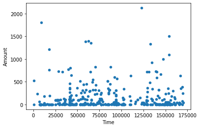

```python
ax = df2.plot.scatter(x='Time',y='Amount')
```

```python
print("From this we can say that {} percent of fraudlent transactions are below 25 EUROS.".format(round(100*len(df2[df2['Amount'] < 25])/len(df2))))
```

```
From this we can say that 56 percent of fraudlent transactions are below 25 EUROS.
```

```python
class_0 = df.loc[df['Class'] == 0]["Time"]
class_1 = df.loc[df['Class'] == 1]["Time"]

hist_data = [class_0, class_1]
group_labels = ['Not Fraud', 'Fraud']

fig = ff.create_distplot(hist_data, group_labels, show_hist=False, show_rug=False)
fig['layout'].update(title='Credit Card Transactions Time Density Plot', xaxis=dict(title='Time [s]'))
iplot(fig, filename='dist_only')
```

[interactive chart not shown]

From the above plot we can conclude that for every 12 hours there rate of fraudlent transactions have been increased. From that analysis we can conclude that in given 48 hours of transactions high rate of Fraudlent transaction occur during midnights. We can also minimum rate of fraudlent transactions are occuring at any time.

```python
cor = df.corr()
```

```python
y = cor['Class'].values
x = cor.index.values
```

```
([0,
  1,
  2,
  3,
  4,
  5,
  6,
  7,
  8,
  9,
  10,
  11,
  12,
  13,
  14,
  15,
  16,
  17,
  18,
  19,
  20,
  21,
  22,
  23,
  24,
  25,
  26,
  27,
  28,
  29,
  30],
 <a list of 31 Text xticklabel objects>)
```

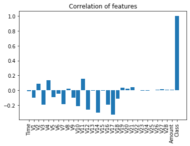

```python
plt.title("Correlation of features")
plt.bar(x, y)
plt.xticks(rotation=90)
```

Above we caluclate Correlation with class for different features from that we can say that if feature value is high for V2, V4, V11 then the chance of of fraudlent transaction is more and for features like V1, V3, V5, V7, V14, V17 if feature value is less the chance of becoming fradulent transaction is more.

### Data Modelling

```python
X = df.drop(['Class', 'Time', 'Amount', 'V8', 'V15', 'V16', 'V22', 'V23', 'V24', 'V25', 'V26', 'V27', 'V28'], axis = 1)
y = df['Class']
```

```python
X_train, X_test, y_train, y_test = train_test_split(X, y, test_size = 0.2, random_state= 42)
clf = RandomForestClassifier()
clf.fit(X_train, y_train)
y_pred_test = clf.predict(X_test)
acc = accuracy_score(y_test, y_pred_test)
print("Accuracy Score for the test data is", acc*100)
cm = confusion_matrix(y_test, y_pred_test)
cm
```

```
Accuracy Score for the test data is 99.95786664794073
```

```
array([[56862,     2],
       [   22,    76]], dtype=int64)
```

Here the data is largely imbalanced that is non fraud transactions are very high this may lead to overfitting of the model. If we can get more data we can get optimum model.

### User Experience

[figure not shown]